# `Image classification using CNNs in Keras - Weed vs Crop`

## `Domain:`

Agriculture

## `Context:`

Can you differentiate a weed from a crop seedling? The ability to do so effectively can mean better crop yields and better stewardship of the environment. The Aarhus University Signal Processing group, in collaboration with University of Southern Denmark, has recently released a dataset containing images of approximately 960 unique plants belonging to 12 species at several growth stages.

## `Data Description:`

We are provided with a dataset of images of plant seedlings at various stages of grown. Each image has a filename that is its unique id. The dataset comprises 12 plant species. The goal of the project is to create a classifier capable of determining a plant's species from a photo. The list of species is as follows:

- Black-grass
- Charlock
- Cleavers
- Common Chickweed
- Common wheat
- Fat Hen
- Loose Silky-bent
- Maize
- Scentless Mayweed
- Shepherds Purse
- Small-flowered Cranesbill
- Sugar beet

**File descriptions**

- images.npy
- Label.csv

## `Goal:`

The goal of the project is to create a classifier capable of determining a plant's species from a photo.

## `Steps and tasks`

1. Import the libraries, load dataset, print shape of data, visualize the images in dataset.
2. Data Pre-processing
3. Make data compatible
4. Building CNN
5. Fit and evaluate model and print confusion matrix
6. Visualize predictions
7. Summary

## 1. Import the libraries, load dataset, print shape of data, visualize the images in dataset.

### Import libraries

```python
# Basic imports
import pandas as pd
import numpy as np

# Plots
import matplotlib.pyplot as plt
%matplotlib inline
import seaborn as sns

import warnings
warnings.filterwarnings('ignore')

from IPython.core.display import display
```

```python
from sklearn.metrics import classification_report, confusion_matrix
```

```python
import cv2
import tensorflow as tf
from tensorflow.keras import datasets, models, layers, optimizers
from tensorflow.keras.callbacks import ModelCheckpoint, EarlyStopping, ReduceLROnPlateau
```

### Load data and print shapes

```python
images = np.load("images.npy")
images.shape
```

```
(4750, 128, 128, 3)
```

```python
labels_df = pd.read_csv('Labels.csv')
labels = labels_df['Label'].values
labels.shape
```

```
(4750,)
```

**Insights:**

- As we can see we have **4750** color images **128 x 128**. Also the same amount of labels.

### Distribution

Let's first see the distribution of the species

```python
def plot_counts_percentages(array):
    total_greens = array.shape[0]
    names, counts = np.unique(labels, return_counts = True)
    idxs = counts.argsort()
    order=names[idxs[::-1]]
    chart = sns.countplot(x=array, palette='muted', order=order);
    chart.set(xlabel='', ylabel='Count')
    chart.set_xticklabels(chart.get_xticklabels(),  rotation=90)
    for p in chart.patches:
        height = p.get_height()
        chart.text(p.get_x() + p.get_width()/2., height + 3, '{:1.2f}'.format((height/total_greens)*100), ha='center')
```

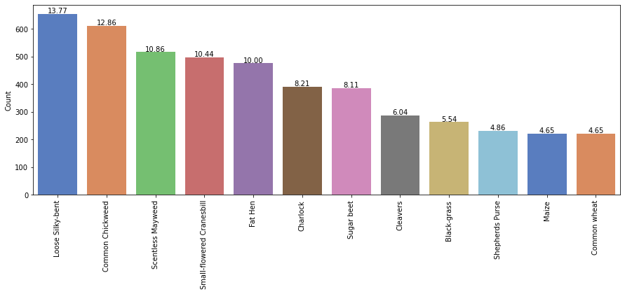

```python
plt.figure(figsize=(15,5))
plot_counts_percentages(labels)
plt.show()
```

**Insights:**

- Easy to see the uneven distribution of the species in the dataset, we could try to balance the set to get better predictions out of our model, but this is not a requirement for this project.

### Visualize the images

```python
def cv2_imshow(ocv_img, title=''):
    h, w = ocv_img.shape[:2]
    h = (h % 100) /5
    w = (w % 100) /5
    plt.figure(figsize=(h,w))
    # When the image file is read with the OpenCV function imread(), the order of colors is BGR,
    # to display it with matplotlib we want to convert it to RGB
    img = cv2.cvtColor(ocv_img, cv2.COLOR_BGR2RGB);
    plt.xticks([])
    plt.yticks([])
    if title:
        plt.title(title)
    plt.imshow(img)
    plt.show()
```

```python
def show_select_2x3(imgs, labels, indices):
    rows = 2
    cols = 3
    plt.figure(figsize=(15,10))

    for idx, index in enumerate(indices):
        plt.subplot(rows, cols, idx+1)
        plt.xticks([])
        plt.yticks([])
        plt.imshow(cv2.cvtColor(imgs[index], cv2.COLOR_BGR2RGB))
        plt.title(labels[index])

    plt.show()
```

Let's pick and visualaze a few images based on index with their respective labels

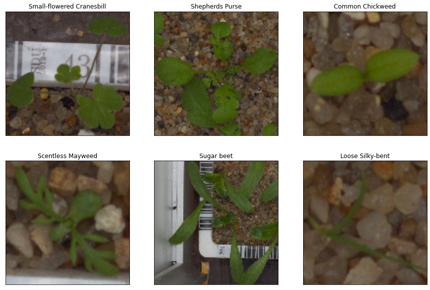

```python
show_select_2x3(images, labels, [11, 1000, 2000, 3000, 3500, 4700])
```

Now let's display first 6 images of **Common wheat**

[figure not shown]

```python
common_wheat_indices = [i for i, x in enumerate(labels) if x == "Common wheat"][:6]
show_select_2x3(images, labels, common_wheat_indices)
```

And first 6 images of **Cleavers**

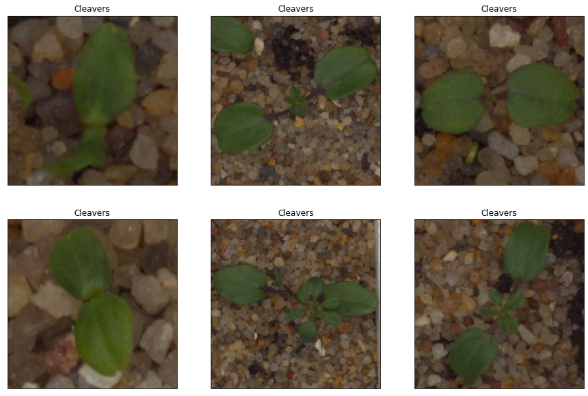

```python
cleavers_indices = [i for i, x in enumerate(labels) if x == "Cleavers"][:6]
show_select_2x3(images, labels, cleavers_indices)
```

**Insights:**

- We can easily access and display each particular image by index and by species type.

## 2. Data Pre-processing

### Gaussian blurring

We want our images to be less noisy. We can achieve that by applying a low pass filter which will smooth the image.

**Gaussian Blurring** is a widely used technique in graphics software, typically to **reduce image noise** and **reduce detail**. It is also used as a preprocessing stage before applying machine learning algorithms or deep learning models. We need to specify the width and height of the **kernel** which should be **positive and odd**. Also the standard deviation in the X and Y directions, sigmaX and sigmaY respectively. If only sigmaX is specified, sigmaY is taken as equal to sigmaX.

```python
img_gauss = [None] * images.shape[0]
for index, img in enumerate(images):
    img_gauss[index] = cv2.GaussianBlur(img, (5, 5), 2)
img_gauss = np.array(img_gauss)
```

### Normalize data

We need to normalize our data as it is always required in neural network models. We can achieve this by dividing the RGB codes by 255 (which is the maximum RGB code minus the minimum RGB code). Important that the values are float so that we can get decimal points after division.

```python
img_norm_gauss = img_gauss.astype('float32') / 255
img_norm_gauss[0]
```

```
array([[[0.15686275, 0.21568628, 0.29803923],
        [0.17254902, 0.23137255, 0.30980393],
        [0.20392157, 0.2627451 , 0.3372549 ],
        ...,
        [0.30588236, 0.3647059 , 0.42745098],
        [0.30980393, 0.36862746, 0.42745098],
        [0.30980393, 0.36862746, 0.42745098]],

       [[0.15686275, 0.21568628, 0.3019608 ],
        [0.17254902, 0.23137255, 0.3137255 ],
        [0.20392157, 0.26666668, 0.34117648],
        ...,
        [0.30588236, 0.3647059 , 0.42745098],
        [0.30980393, 0.36862746, 0.42745098],
        [0.30980393, 0.36862746, 0.42745098]],

       [[0.16470589, 0.22745098, 0.30588236],
        [0.1764706 , 0.24313726, 0.32156864],
        [0.21568628, 0.2784314 , 0.34901962],
        ...,
        [0.30588236, 0.3647059 , 0.41960785],
        [0.30980393, 0.3647059 , 0.42352942],
        [0.30980393, 0.36862746, 0.42352942]],

       ...,

       [[0.15294118, 0.21176471, 0.2784314 ],
        [0.15686275, 0.21176471, 0.28235295],
        [0.16078432, 0.21568628, 0.28235295],
        ...,
        [0.21176471, 0.2784314 , 0.3529412 ],
        [0.23137255, 0.29803923, 0.3647059 ],
        [0.23921569, 0.3019608 , 0.36862746]],

       [[0.16078432, 0.21960784, 0.28235295],
        [0.16470589, 0.22352941, 0.28627452],
        [0.16470589, 0.22352941, 0.28627452],
        ...,
        [0.19607843, 0.26666668, 0.34117648],
        [0.21568628, 0.2901961 , 0.35686275],
        [0.22745098, 0.29803923, 0.3647059 ]],

       [[0.16470589, 0.22352941, 0.28627452],
        [0.16862746, 0.22352941, 0.28627452],
        [0.16862746, 0.22352941, 0.28627452],
        ...,
        [0.1882353 , 0.2627451 , 0.3372549 ],
        [0.21176471, 0.28627452, 0.3529412 ],
        [0.21960784, 0.29411766, 0.36078432]]], dtype=float32)
```

### Visualize data after pre-processing

Let's visualaze the same 6 images after we applied the our pre-processing steps:

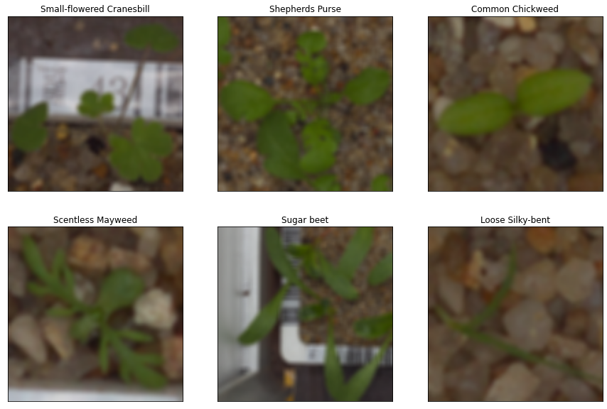

```python
show_select_2x3(img_norm_gauss, labels, [11, 1000, 2000, 3000, 3500, 4700])
```

**Insights:**

- Easy to see that details become blurry, which should help our model to detect important features/edges.

## 3. Make data compatible

### Convert labels to one-hot-vectors

There is a number of techniques how we can convert labels to one-hot encoded vectors. Here **LabelBinarizer** looks like a good fit for its abbility to go back and forth between encodings.

```python
from sklearn.preprocessing import LabelBinarizer

lb_encoder = LabelBinarizer()

label_one_hot_vectors = lb_encoder.fit_transform(labels)
label_one_hot_vectors
```

```
array([[0, 0, 0, ..., 0, 1, 0],
       [0, 0, 0, ..., 0, 1, 0],
       [0, 0, 0, ..., 0, 1, 0],
       ...,
       [0, 0, 0, ..., 0, 0, 0],
       [0, 0, 0, ..., 0, 0, 0],
       [0, 0, 0, ..., 0, 0, 0]])
```

Now it is easy to see the whole matrix for all 12 species:

```python
lb_encoder.transform(np.unique(labels))
```

```
array([[1, 0, 0, 0, 0, 0, 0, 0, 0, 0, 0, 0],
       [0, 1, 0, 0, 0, 0, 0, 0, 0, 0, 0, 0],
       [0, 0, 1, 0, 0, 0, 0, 0, 0, 0, 0, 0],
       [0, 0, 0, 1, 0, 0, 0, 0, 0, 0, 0, 0],
       [0, 0, 0, 0, 1, 0, 0, 0, 0, 0, 0, 0],
       [0, 0, 0, 0, 0, 1, 0, 0, 0, 0, 0, 0],
       [0, 0, 0, 0, 0, 0, 1, 0, 0, 0, 0, 0],
       [0, 0, 0, 0, 0, 0, 0, 1, 0, 0, 0, 0],
       [0, 0, 0, 0, 0, 0, 0, 0, 1, 0, 0, 0],
       [0, 0, 0, 0, 0, 0, 0, 0, 0, 1, 0, 0],
       [0, 0, 0, 0, 0, 0, 0, 0, 0, 0, 1, 0],
       [0, 0, 0, 0, 0, 0, 0, 0, 0, 0, 0, 1]])
```

**Insights:**

- We transfomed our labels into the form and shape that is compatible with input requirements for our future CNN model.

### Print the label for "y_train[0]"

Since the order in the project describtion is enforced to **a,b,c...** we don't have **y_train** yet. Our one-hot encoded labels reside in the **label_one_hot_vectors**, so here is the first label:

```python
label_one_hot_vectors[0]
```

```
array([0, 0, 0, 0, 0, 0, 0, 0, 0, 0, 1, 0])
```

### Split the dataset into training, testing, and validation set.

Keras is perfectly capable of doing **validation_split** itself, however, we are required to do it manually by the project describtion. So first we split our pre-processed images and labels into training and testing set with using ratio = 0.3. And then we split testing set into new testing and validation sets with ratio = 0.5 Let's do it now.

```python
from sklearn.model_selection import train_test_split
seed=33

# split dataset into training and test set
X_train, X_test, y_train, y_test = train_test_split(img_norm_gauss, label_one_hot_vectors,  test_size=0.30, random_state=seed)

# split testing set into new testing  and validation sets
X_test, X_valid, y_test, y_valid = train_test_split(X_test, y_test, test_size=0.5, random_state=seed)
```

```python
print(f'{len(X_train)} - {(len(X_train)/len(img_norm_gauss))*100:0.1f}% of data is in training set')
print(f'{len(X_test)} - {(len(X_test)/len(img_norm_gauss))*100:0.1f}% of data is in testing set')
print(f'{len(X_valid)} - {(len(X_valid)/len(img_norm_gauss))*100:0.1f}% of data is in validation set')
```

```
3325 - 70.0% of data is in training set
712 - 15.0% of data is in testing set
713 - 15.0% of data is in validation set
```

**Insights:**

- We made our split according to the requirements 70/15/15 which corresponds to training/testing/validation sets.

### Check the shape of data

As per project requirement we have to make sure that data is stored in the compatible structures & reshape it if needed. Let's print out the shapes and check.

```python
X_train = np.array(X_train)
X_train.shape
```

```
(3325, 128, 128, 3)
```

```python
X_test = np.array(X_test)
X_test.shape
```

```
(712, 128, 128, 3)
```

```python
X_valid = np.array(X_valid)
X_valid.shape
```

```
(713, 128, 128, 3)
```

```python
y_train = np.array(y_train)
y_train.shape
```

```
(3325, 12)
```

```python
y_test = np.array(y_test)
y_test.shape
```

```
(712, 12)
```

```python
y_valid = np.array(y_valid)
y_valid.shape
```

```
(713, 12)
```

**Insights:**

- As we can observe everything is ready to be cosumed and it is in compatible shape.

## 4. Building CNN

## First attempt

As per project requirements we will present one of the models that does not provide the best results and then improve it.

### Define layers

```python
classifier = models.Sequential()

classifier.add(layers.Conv2D(32, (5, 5), activation="relu", input_shape=X_train.shape[1:]))
classifier.add(layers.MaxPooling2D((2, 2)))
classifier.add(layers.Conv2D(64, (5, 5), activation="relu"))
classifier.add(layers.MaxPooling2D((2, 2)))
classifier.add(layers.Conv2D(64, (3, 3), activation="relu"))
classifier.add(layers.MaxPooling2D((2, 2)))

classifier.add(layers.Flatten())
classifier.add(layers.Dense(256, activation="relu"))
classifier.add(layers.Dense(12, activation="softmax"))

classifier.summary()
```

```
Model: "sequential"
_________________________________________________________________
Layer (type)                 Output Shape              Param #
=================================================================
conv2d (Conv2D)              (None, 124, 124, 32)      2432
_________________________________________________________________
max_pooling2d (MaxPooling2D) (None, 62, 62, 32)        0
_________________________________________________________________
conv2d_1 (Conv2D)            (None, 58, 58, 64)        51264
_________________________________________________________________
max_pooling2d_1 (MaxPooling2 (None, 29, 29, 64)        0
_________________________________________________________________
conv2d_2 (Conv2D)            (None, 27, 27, 64)        36928
_________________________________________________________________
max_pooling2d_2 (MaxPooling2 (None, 13, 13, 64)        0
_________________________________________________________________
flatten (Flatten)            (None, 10816)             0
_________________________________________________________________
dense (Dense)                (None, 256)               2769152
_________________________________________________________________
dense_1 (Dense)              (None, 12)                3084
=================================================================
Total params: 2,862,860
Trainable params: 2,862,860
Non-trainable params: 0
_________________________________________________________________
```

### Set optimizer and loss function

```python
classifier.compile(loss='categorical_crossentropy', optimizer='adam', metrics=['accuracy'])
```

### Evaluate model, predict and print Confusion Matrix

```python
history = classifier.fit(X_train, y_train, batch_size=10, epochs=10, validation_data = (X_valid, y_valid))
```

```python
training_evals = classifier.evaluate(X_train, y_train, verbose=0)
validation_evals = classifier.evaluate(X_valid, y_valid, verbose=0)
testing_evals = classifier.evaluate(X_test, y_test, verbose=0)
```

```python
classifier_evaluation = pd.DataFrame(
        [training_evals, validation_evals, testing_evals],
        columns=classifier.metrics_names,
        index=['Training', 'Validation', 'Testing']
    )

display(classifier_evaluation)
```

|  | loss | accuracy |
| --- | --- | --- |
| Training | 0.106319 | 0.960301 |
| Validation | 1.157182 | 0.744741 |
| Testing | 1.223274 | 0.752809 |

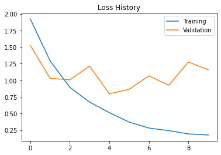

```python
plt.plot(history.history['loss'], label='Training')
plt.plot(history.history['val_loss'], label='Validation')
plt.title('Loss History')
plt.legend()
plt.show()
```

```python
y_pred_proba = classifier.predict(X_test)
y_pred_labels = lb_encoder.inverse_transform(y_pred_proba, threshold=0.5)
y_test_labels = lb_encoder.inverse_transform(y_test, threshold=None)

cm = confusion_matrix(y_test_labels, y_pred_labels)
print(cm)
```

```
[[ 3  0  0  0  5  2 24  0  1  0  0  2]
 [ 0 53  1  0  0  2  0  0  1  4  8  2]
 [ 0  3 40  0  0  0  0  0  1  1  1  0]
 [ 0  0  0 81  2  0  0  0  0  0  1  2]
 [ 1  0  1  0 13  1  7  0  1  0  1  1]
 [ 0  0  2  3  0 55  0  1  1  2  1  2]
 [ 3  0  0  1  2  5 85  0  2  0  0  0]
 [ 0  0  1  6  2  0  1 22  0  2  1  5]
 [ 1  0  2 11  1  1  2  1 59  5  0  0]
 [ 0  0  1  8  0  3  0  0  2 21  1  0]
 [ 0  0  0  1  0  0  0  1  0  0 67  0]
 [ 0  0  0  1  0  7  1  0  1  2  4 37]]
```

**Insights:**

- As we can see from the training history **accuracy** metric and **loss** are quick to overfit, starting around **epoch 3-4**.
- Although accuracy of **0.75** on the testing set can be considered good, we have pretty **heigh loss**.

**Points of Improvement:**

- As our model is overfitting we will add **Dropout** layers for the regularization.
- Also since evry convolution layer changes the data in a way that does not guarantee normalization, we will add **BatchNormalization** layers after each of them.
- Let us leave as much useful information as we can, let us include the edges in the training process too.
- Further we have the **learning rate** for **Adam** optimizer which defaults to 0.001. Let us give it a **smaller rate** and help it automatically decrease if it reaches stagnation. As we are decreasing the learning rate we expect the training to take longer time and so we will **increase the number of epochs** too and at the same time we provide an **early exit** if we see that our loss stopped improving.
- To finish our proposals off, we probably want to save & use the **best weights** that we encountered during the training, we will define our best weights at the best loss.

## Best attempt

Now let us present our best attempt at the model configuration.

### Define layers

```python
classifier = models.Sequential()

classifier.add(layers.Conv2D(32, (5, 5), padding='same', activation="relu", input_shape=X_train.shape[1:]))
classifier.add(layers.BatchNormalization())
classifier.add(layers.MaxPooling2D((2, 2)))
classifier.add(layers.Conv2D(64, (5, 5), padding='same', activation="relu"))
classifier.add(layers.BatchNormalization())
classifier.add(layers.MaxPooling2D((2, 2)))
classifier.add(layers.Conv2D(64, (3, 3), padding='same', activation="relu"))
classifier.add(layers.BatchNormalization())
classifier.add(layers.MaxPooling2D((2, 2)))
classifier.add(layers.Conv2D(64, (3, 3), padding='same', activation="relu"))
classifier.add(layers.BatchNormalization())
classifier.add(layers.MaxPooling2D((2, 2)))
classifier.add(layers.Dropout(0.5))

classifier.add(layers.Flatten())
classifier.add(layers.Dense(256, activation="relu"))
classifier.add(layers.Dropout(0.5))
classifier.add(layers.Dense(12, activation="softmax"))

classifier.summary()
```

```
Model: "sequential_3"
_________________________________________________________________
Layer (type)                 Output Shape              Param #
=================================================================
conv2d_11 (Conv2D)           (None, 128, 128, 32)      2432
_________________________________________________________________
batch_normalization_8 (Batch (None, 128, 128, 32)      128
_________________________________________________________________
max_pooling2d_11 (MaxPooling (None, 64, 64, 32)        0
_________________________________________________________________
conv2d_12 (Conv2D)           (None, 64, 64, 64)        51264
_________________________________________________________________
batch_normalization_9 (Batch (None, 64, 64, 64)        256
_________________________________________________________________
max_pooling2d_12 (MaxPooling (None, 32, 32, 64)        0
_________________________________________________________________
conv2d_13 (Conv2D)           (None, 32, 32, 64)        36928
_________________________________________________________________
batch_normalization_10 (Batc (None, 32, 32, 64)        256
_________________________________________________________________
max_pooling2d_13 (MaxPooling (None, 16, 16, 64)        0
_________________________________________________________________
conv2d_14 (Conv2D)           (None, 16, 16, 64)        36928
_________________________________________________________________
batch_normalization_11 (Batc (None, 16, 16, 64)        256
_________________________________________________________________
max_pooling2d_14 (MaxPooling (None, 8, 8, 64)          0
_________________________________________________________________
dropout_4 (Dropout)          (None, 8, 8, 64)          0
_________________________________________________________________
flatten_3 (Flatten)          (None, 4096)              0
_________________________________________________________________
dense_6 (Dense)              (None, 256)               1048832
_________________________________________________________________
dropout_5 (Dropout)          (None, 256)               0
_________________________________________________________________
dense_7 (Dense)              (None, 12)                3084
=================================================================
Total params: 1,180,364
Trainable params: 1,179,916
Non-trainable params: 448
_________________________________________________________________
```

**Insights:**

- After several experiments the above model showed the best results. Here we decided to go with a few pairs of **Conv2D** and **MaxPooling2D** layers. Also since there is no guarantee that all the values a properly scaled after a convolution layer we use **BatchNormalization** layers to remedy that. We also have couple of **Dropout** layers for the regularization purposes. Before passing the results to the dense neural network we reshape the data into the appropriate 1D vector format.
- Also in this CNN we choose not to loose any information on the edges and so we always add the relative padding.

### Set optimizer and loss function

Per project description we need to use **Adam optimizer**, we set loss function to **categorical crossentropy** as it is a logical choice for our problem.

```python
optimizer = tf.keras.optimizers.Adam(learning_rate=0.0001)

early_stopping = EarlyStopping(monitor='val_loss', min_delta=0.001, patience=3)
checkpoint = ModelCheckpoint(filepath='./checkpoint_filepath', monitor='val_loss', verbose=1, save_best_only=True, save_weights_only=True, mode='auto')
reduce_lr = ReduceLROnPlateau(monitor='val_loss', factor=0.5, patience=1, verbose=1, mode='auto', min_lr=0.000001)

classifier.compile(loss='categorical_crossentropy', optimizer=optimizer, metrics=['accuracy'])
```

**Insights:**

- One of the improvements worth noticing is the introduction of the **ReduceLROnPlateau** callback. To help our model to recover from learning stagnation, we introduce this callback with the **validation loss metric** and **patience** set to **1** epoch.
- Also we will keep the best **weights** our model encountered during the training at **lowes loss** & provide an **early exit**.

## 5. Fit and evaluate model and print confusion matrix.

### Fit the model

```python
history = classifier.fit(X_train, y_train, batch_size=10, epochs=40,
               validation_data = (X_valid, y_valid),
               callbacks = [checkpoint, early_stopping, reduce_lr])
```

```
Epoch 00001: val_loss improved from inf to 3.00254, saving model to ./checkpoint_filepath
Epoch 00002: val_loss improved from 3.00254 to 1.61206, saving model to ./checkpoint_filepath
Epoch 00003: val_loss improved from 1.61206 to 1.37148, saving model to ./checkpoint_filepath
Epoch 00004: val_loss improved from 1.37148 to 1.25810, saving model to ./checkpoint_filepath
Epoch 00005: val_loss improved from 1.25810 to 1.20916, saving model to ./checkpoint_filepath
Epoch 00006: val_loss improved from 1.20916 to 1.05138, saving model to ./checkpoint_filepath
Epoch 00007: val_loss improved from 1.05138 to 0.84355, saving model to ./checkpoint_filepath
Epoch 00008: val_loss improved from 0.84355 to 0.80670, saving model to ./checkpoint_filepath
Epoch 00009: val_loss did not improve from 0.80670

Epoch 00009: ReduceLROnPlateau reducing learning rate to 4.999999873689376e-05.
Epoch 00010: val_loss improved from 0.80670 to 0.68739, saving model to ./checkpoint_filepath
Epoch 00011: val_loss improved from 0.68739 to 0.62781, saving model to ./checkpoint_filepath
Epoch 00012: val_loss did not improve from 0.62781

Epoch 00012: ReduceLROnPlateau reducing learning rate to 2.499999936844688e-05.
Epoch 00013: val_loss improved from 0.62781 to 0.56562, saving model to ./checkpoint_filepath
Epoch 00014: val_loss improved from 0.56562 to 0.52303, saving model to ./checkpoint_filepath
Epoch 00015: val_loss did not improve from 0.52303

Epoch 00015: ReduceLROnPlateau reducing learning rate to 1.249999968422344e-05.
Epoch 00016: val_loss improved from 0.52303 to 0.50924, saving model to ./checkpoint_filepath
Epoch 00017: val_loss improved from 0.50924 to 0.49967, saving model to ./checkpoint_filepath
Epoch 00018: val_loss improved from 0.49967 to 0.49894, saving model to ./checkpoint_filepath
Epoch 00019: val_loss improved from 0.49894 to 0.47470, saving model to ./checkpoint_filepath
Epoch 00020: val_loss did not improve from 0.47470

Epoch 00020: ReduceLROnPlateau reducing learning rate to 6.24999984211172e-06.
Epoch 00021: val_loss improved from 0.47470 to 0.47017, saving model to ./checkpoint_filepath
Epoch 00022: val_loss did not improve from 0.47017

Epoch 00022: ReduceLROnPlateau reducing learning rate to 3.12499992105586e-06.
Epoch 00023: val_loss improved from 0.47017 to 0.46386, saving model to ./checkpoint_filepath
Epoch 00024: val_loss did not improve from 0.46386

Epoch 00024: ReduceLROnPlateau reducing learning rate to 1.56249996052793e-06.
Epoch 00025: val_loss improved from 0.46386 to 0.46319, saving model to ./checkpoint_filepath
Epoch 00026: val_loss did not improve from 0.46319

Epoch 00026: ReduceLROnPlateau reducing learning rate to 1e-06.
```

```python
classifier.load_weights('./checkpoint_filepath')
```

```
<tensorflow.python.training.tracking.util.CheckpointLoadStatus at 0x7f9d9f89a6d0>
```

### Evaluate model, predict and print Confusion Matrix

```python
training_evals = classifier.evaluate(X_train, y_train, verbose=0)
validation_evals = classifier.evaluate(X_valid, y_valid, verbose=0)
testing_evals = classifier.evaluate(X_test, y_test, verbose=0)
```

```python
classifier_evaluation = pd.DataFrame(
        [training_evals, validation_evals, testing_evals],
        columns=classifier.metrics_names,
        index=['Training', 'Validation', 'Testing']
    )

display(classifier_evaluation)
```

|  | loss | accuracy |
| --- | --- | --- |
| Training | 0.224795 | 0.948872 |
| Validation | 0.463186 | 0.851332 |
| Testing | 0.440290 | 0.859551 |

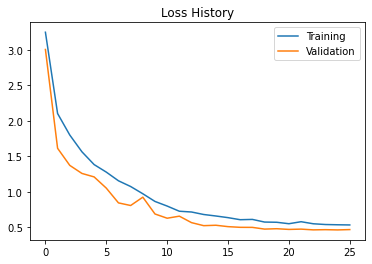

```python
plt.plot(history.history['loss'], label='Training')
plt.plot(history.history['val_loss'], label='Validation')
plt.title('Loss History')
plt.legend()
plt.show()
```

**Insights:**

- We reached a pretty good accuracy of **~0.86** on our testing set. We had a good reduction in loss up until **~epoch 10**, our loss is **0.44** on the testing set.
- Our **ReduceLROnPlateau** callback helped us to reduce learing rate several times when the loss stoped improving and it helped our model to recover. Also as we can see further reduction of the learning rate beyond **1e-06** did not help.
- Our **EarlyStopping** call back helped us to stop (epoch 26) when loss stoped descreasing.
- Finally our **ModelCheckpoint** allowed us to save the best weights.
- No overfitting.
- **Overall** we significantly improved over our elier models, we **reduced loss twice** and improved **accuracy** from **0.75** to **0.86**.

Let's **make predictions** for our testing dataset

```python
y_pred_proba = classifier.predict(X_test)
y_pred_proba[0]
```

```
array([1.2955992e-09, 9.9919540e-01, 1.7716742e-06, 6.5717822e-09,
       2.7025482e-09, 1.6850288e-06, 1.5605710e-10, 3.4435582e-06,
       7.7904024e-06, 6.9978210e-05, 3.5899351e-04, 3.6091692e-04],
      dtype=float32)
```

```python
y_pred_labels = lb_encoder.inverse_transform(y_pred_proba, threshold=0.5)
y_pred_labels[0]
```

```
'Charlock'
```

```python
y_test_labels = lb_encoder.inverse_transform(y_test, threshold=None)
y_test_labels[0]
```

```
'Charlock'
```

So now when we have our true & predicted labels in the same format, let's build our **classification report** and **confusion matrix**

```python
print(classification_report(y_test_labels, y_pred_labels))
```

```
                           precision    recall  f1-score   support

              Black-grass       0.53      0.46      0.49        37
                 Charlock       0.97      0.90      0.93        71
                 Cleavers       0.94      0.96      0.95        46
         Common Chickweed       0.82      0.98      0.89        86
             Common wheat       0.73      0.85      0.79        26
                  Fat Hen       0.92      0.88      0.90        67
         Loose Silky-bent       0.80      0.83      0.81        98
                    Maize       0.91      0.72      0.81        40
        Scentless Mayweed       0.84      0.92      0.88        83
          Shepherds Purse       0.89      0.67      0.76        36
Small-flowered Cranesbill       0.94      0.97      0.96        69
               Sugar beet       0.90      0.85      0.87        53

                 accuracy                           0.86       712
                macro avg       0.85      0.83      0.84       712
             weighted avg       0.86      0.86      0.86       712
```

**Insights:**

- **Accuracy** is very good - **0.86**, hence **Error Rate** is **0.14**.
- **Precision** ranging from **0.53** to **0.97**. Overall good precission for many classes, except **Black-grass**.
- **Reacall** ranging from **0.46** to **0.98**. Again, not the best recall for **Black-grass** only **0.46**, but ok for the rest of the species.

```python
cm = confusion_matrix(y_test_labels, y_pred_labels)
print(cm)
```

```
[[17  0  0  0  3  1 15  0  0  0  0  1]
 [ 0 64  0  0  1  0  0  0  1  2  2  1]
 [ 0  2 44  0  0  0  0  0  0  0  0  0]
 [ 0  0  0 84  1  0  1  0  0  0  0  0]
 [ 0  0  1  0 22  0  2  0  1  0  0  0]
 [ 2  0  1  1  0 59  2  0  1  0  0  1]
 [13  0  0  0  2  1 81  0  1  0  0  0]
 [ 0  0  0  4  0  1  0 29  4  0  0  2]
 [ 0  0  0  5  0  1  0  0 76  1  0  0]
 [ 0  0  0  5  0  0  0  1  5 24  1  0]
 [ 0  0  0  2  0  0  0  0  0  0 67  0]
 [ 0  0  1  1  1  1  0  2  1  0  1 45]]
```

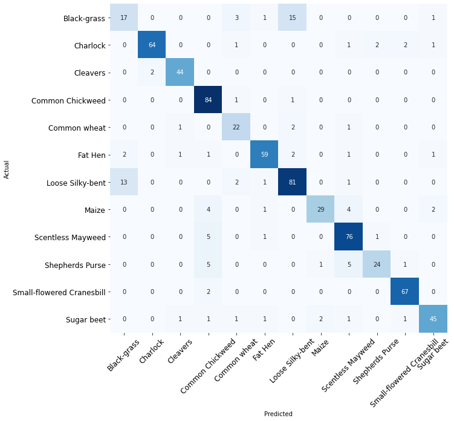

```python
labels_list = np.unique(labels);
df_cm = pd.DataFrame(cm, index = [i for i in labels_list], columns = [i for i in labels_list])

plt.figure(figsize=(10, 10))
heatmap=sns.heatmap(df_cm,  annot = True, cmap='Blues', fmt='d', cbar = False) # mako, YlOrBr, Blues
heatmap.set_xticklabels(heatmap.get_xticklabels(), rotation=45, fontweight='light', fontsize=12)
heatmap.set_yticklabels(heatmap.get_yticklabels(), rotation=0, fontweight='light', fontsize=12)
plt.ylabel('Actual')
plt.xlabel('Predicted')
plt.show()
```

**Insights:**

- We can see that predictions for **Black-grass** often confused with the **Loose Silky-bent**. Even as a human we would have the same difficulty because those two species look very much alike. In our dataset we had almost **14%** of **Loose Silky-bent** samples which probably contributed to ability of our classifier to detect them correctly. However we had only **~5.5%** of **Black-grass** samples.
- The overall situation is better for the rest of the species.

## 6. Visualize predictions

Per project requirements we are going to visualize

- X_test[2]
- X_test[3]
- X_test[33]
- X_test[36]
- X_test[59]

```python
def show_pred_2x3(imgs, labels_true, labels_pred, indices):
    plt.figure(figsize=(16,10))

    for idx, index in enumerate(indices):
        plt.subplot(2, 3, idx+1)
        plt.xticks([])
        plt.yticks([])
        plt.imshow(cv2.cvtColor(imgs[index], cv2.COLOR_BGR2RGB))
        plt.title(f'Index: {index}\nTrue: {labels_true[index]}\nPred: {labels_pred[index]}')

    plt.show()
```

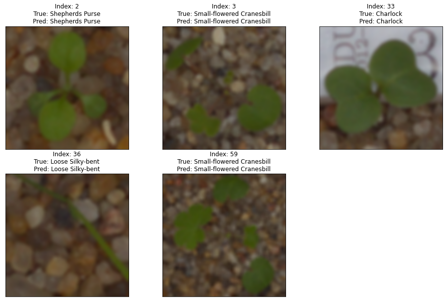

```python
show_pred_2x3(X_test, y_test_labels, y_pred_labels, [2, 3, 33, 36, 59])
```

**Insights:**

- All samples predicted correctly.

## 7. Summary

Overall we were able to build a good claciffier capable of determining plant's species from a photo and accuracy of **~86%**. We used CNN and employed several callback techniques to improve model's performance. Image pre-processing also helped our classifier to achive better results.

It is worth notting that further improvement of the model is possible. We may balance the dataset and applying some more sophisticated image preprocessing techniques. Also, it is well known that for the **classification** purposes we don't need **color images**, we could have actually converted them to grayscale and so, at the very least, reduced the number of parameters to be learned by our CNN.